# Credit Card Fraud Detection

Cecile Guillot

# 1. Introduction

This project is a classification project based on data about credit card fraud. The aim is to detect the fraudulent transaction. The dataset is available here: [dataset](https://www.kaggle.com/mlg-ulb/creditcardfraud). In order to realise this project, R was used. At the end of the project, LIME library helps us to have an idea of the feature importances.

# 2. Data Cleaning

```r
library(dplyr)
library(janitor)
library(naniar)
library(stats)

creditcard <- read.csv("~/Credit_Card_Fraud_Detection/00_raw_data/creditcard.csv",
                       header=FALSE)

creditcard_clean <- clean_names(creditcard)
creditcard_clean <- creditcard_clean[-c(1)]

pct_complete(creditcard_clean)
```

```
## [1] 100
```

# 3. Data Analysis

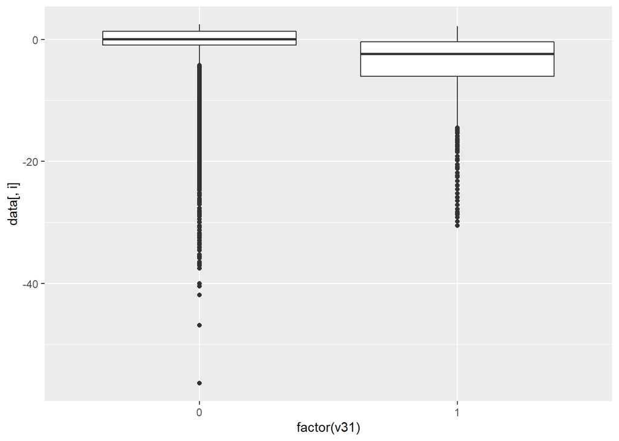

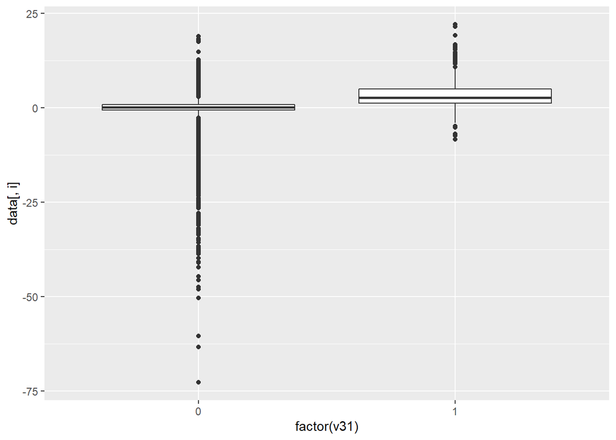

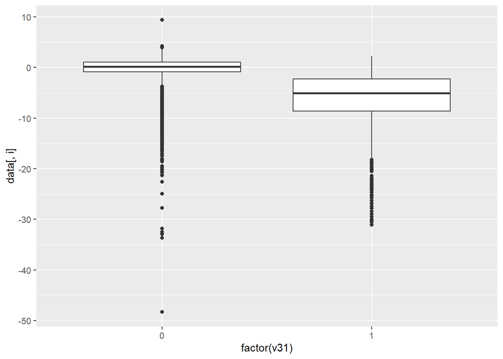

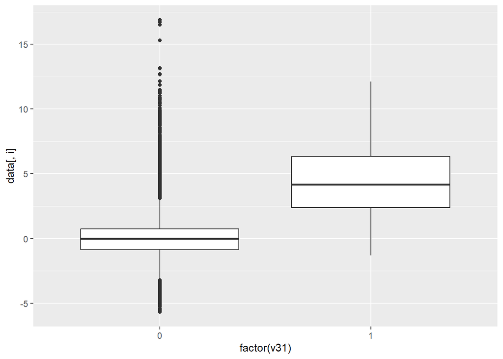

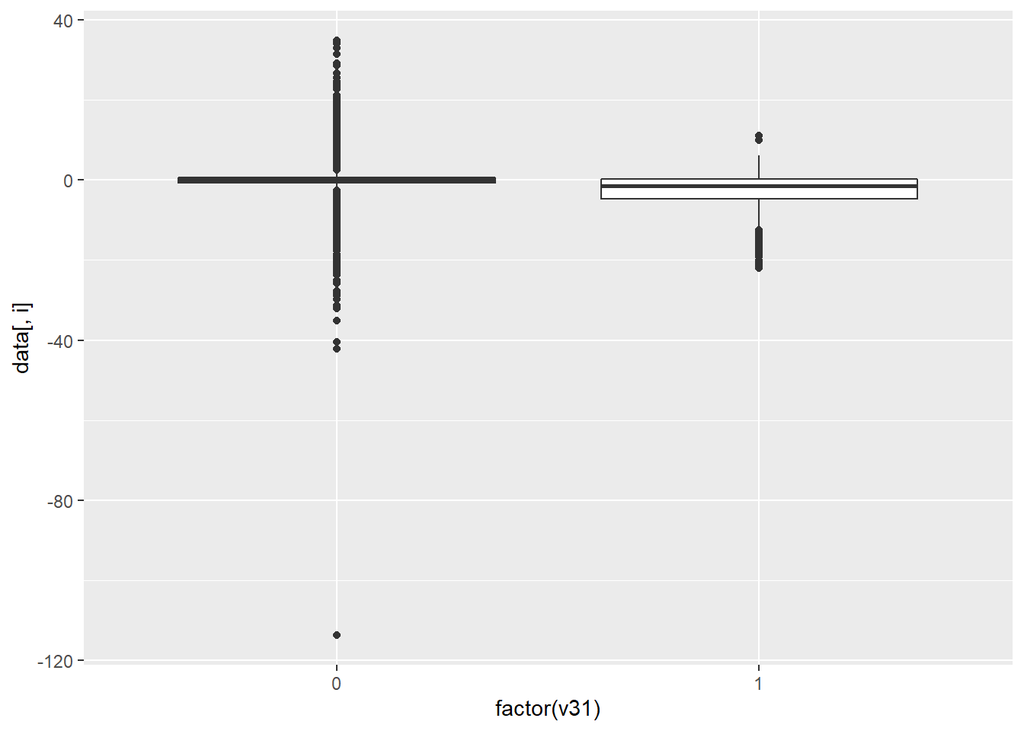

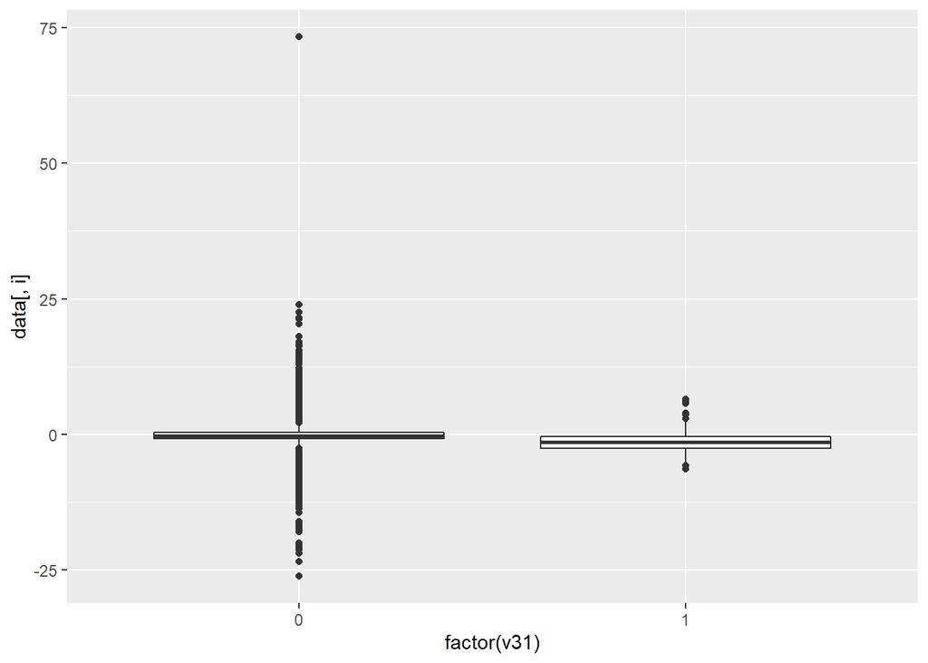

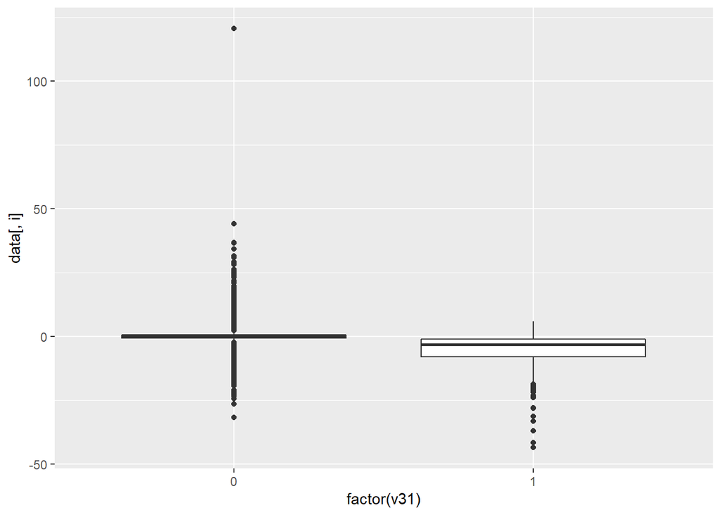

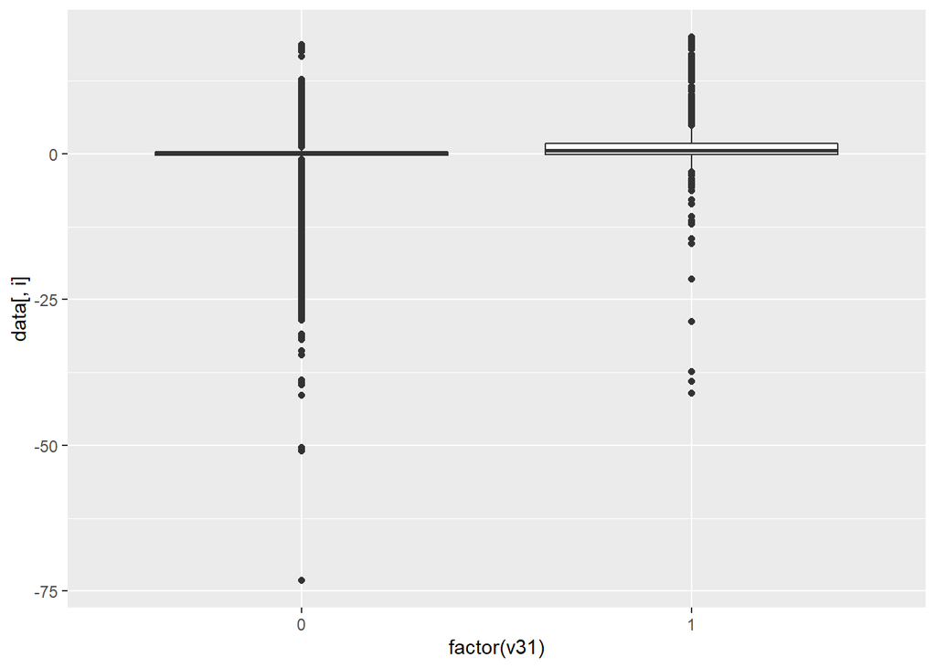

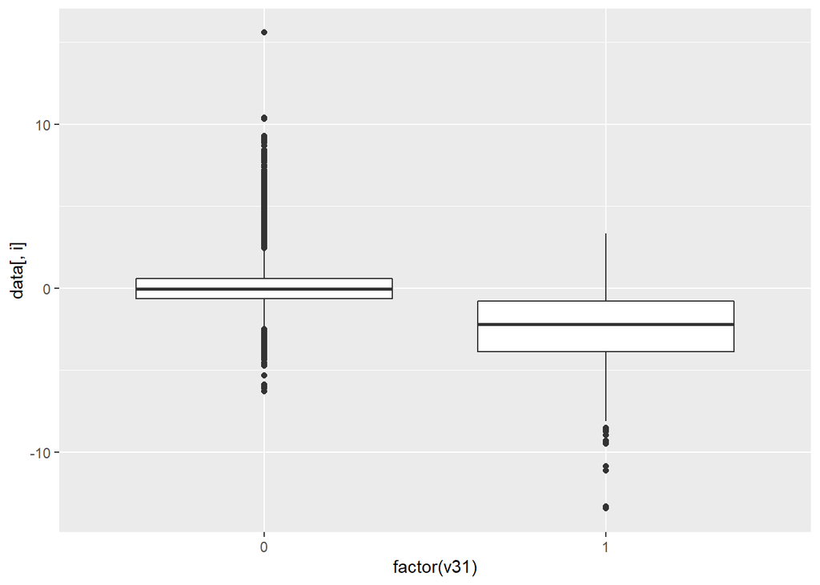

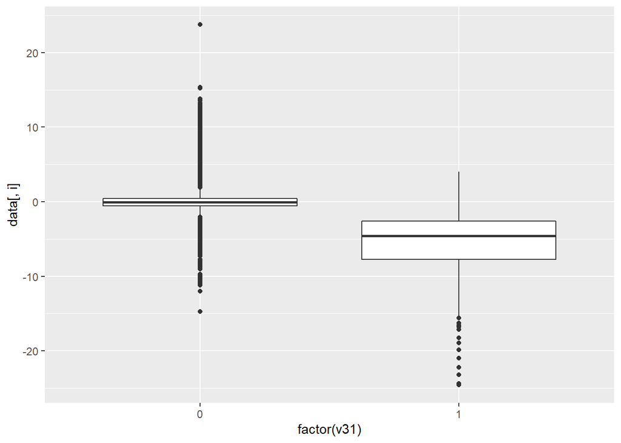

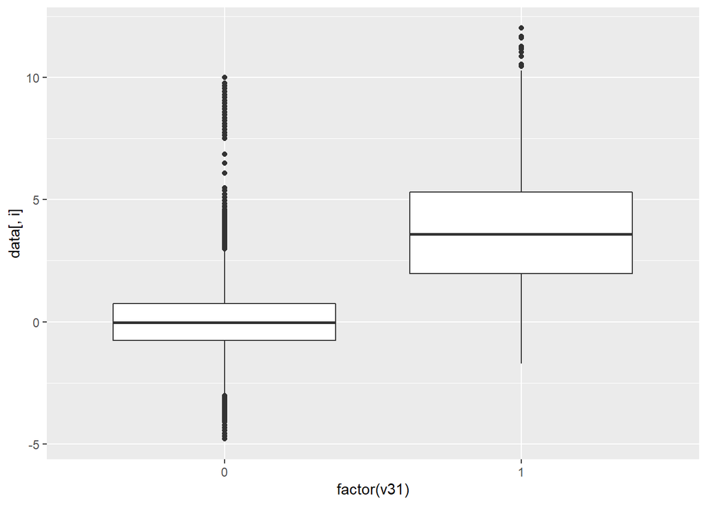

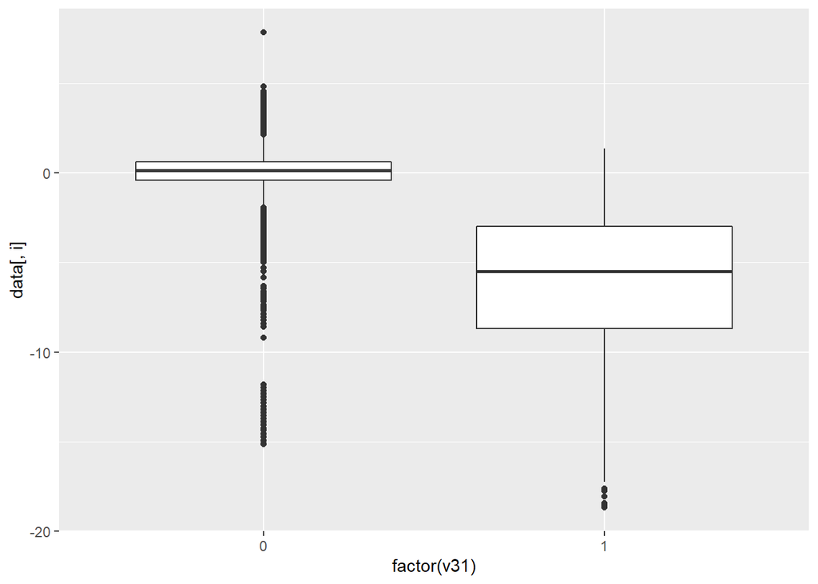

[18 more figures not shown]

```r
library(ggplot2)

data <- read.csv('~/Credit_Card_Fraud_Detection/01_tidy_data/creditcard_clean.csv',
                 header=TRUE)

data <- as.data.frame(sapply(data, as.numeric))

for (i in 1:ncol(data)){
print(ggplot(data, aes(x = factor(v31), y=data[ , i])) +
  geom_boxplot())
  Sys.sleep(2)}
```

Data are composed by 30 variables. The last column (v31) contains the label of the data. For each transaction, 29 variables are available and will be used in the modelising step.

An analysis of the class distribution (fraudulent or not) show an imbalanced between them. More than 99% of the transaction are not fraudulent.

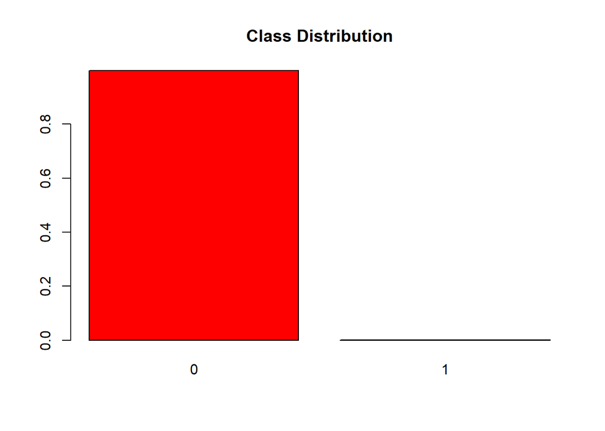

```r
barplot(prop.table(table(data$v31)),
        col = rainbow(2),
        main = "Class Distribution")
```

Thus, we have to make a specific processing before creating the model.

# 4. Modelisation